# Predicción ingresos Apple

miguel González Cobaleda

2020-11-16

# Objetivo

Se debe elegir el modelo ETS y el modelo ARIMA que mejor predice las ventas de Apple, habiendo dejado fuera de la estimación los trimestres del 2017.

Una vez seleccionado el modelo se estimara el modelo con todos los datos y se harán las predicciones del año 2017 y 2018.

## Carga de librerias necesarias

```r
library(ggplot2)
library(forecast)
library(ggfortify)
library(xts)
```

## Carga de los datos

```r
apple <- read.csv("IngresosApple.csv",
                  sep = ";",
                  dec = ",")
# Creación de un vector de fechas
tri <- seq(as.Date('01/04/2008', '%d/%m/%Y'),
           as.Date('30/09/2017', '%d/%m/%Y'),
           by = 'quarter')
```

```r
# Objeto de tipo xts
xIngresos <- xts(apple$Ingresos, order.by = tri)
xIngresos <- to.quarterly(xIngresos)
```

```r
# Objeto de tipo zoo para realizar el forecasting
zIngresos <- as.zoo(xIngresos$xIngresos.Close)
names(zIngresos)='Ingresos'
```

# Visualización de datos

Serie temporal de los ingresos de apple desde el 2Q 2008 hasta el Q3 2017

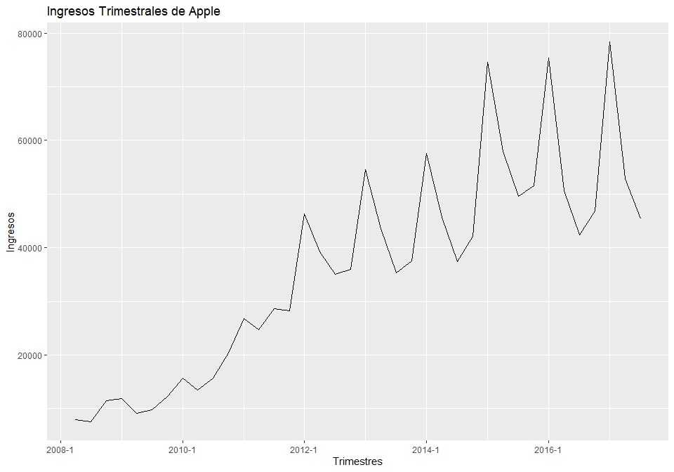

```r
autoplot(zIngresos)+ggtitle('Ingresos Trimestrales de Apple')+xlab('Trimestres')+ylab('Ingresos')
```

Podemos observar como los ingresos de la empresa Apple tienen una clara tendencia ascendente en este periodo, a su vez también se puede ver como ha aumentado la varianza en los ingresos en los últimos trimestres.

# Modelos ETS

Los modelos ETS son diferentes modelos para estudiar y poder predecir series temporales.

```r
cOmit <- 3 # Para indicar que se dejen fuera 3 trimestres
nObs <- length(zIngresos)

# datos eliminando los 3 ultimos trimestres
oIngresos <- window(zIngresos, # datos tipo zoo de los ingresos
  start = index(zIngresos[1]), # indica que empiece en el primer trimestre
  end = index(zIngresos[nObs - cOmit])) # Indica el final, eliminando 3 trimestres del año 2017
```

Mediante los Criterios de Información (IC) vamos a intentar seleccionar el mejor modelo ETS de forma automática.

Los Criterios de Información cuantifican la información residual. Cuanto más información tienen los residuos del modelo mayor es el IC, por lo tanto peor es el modelo.

```r
## Selecciona un modelo ETS de forma automática
etsfit<-ets(oIngresos)
#forecast model
fingresos.ets<-forecast(etsfit)
#Results
summary(fingresos.ets)
```

```
##
## Forecast method: ETS(M,A,M)
##
## Model Information:
## ETS(M,A,M)
##
## Call:
##  ets(y = oIngresos)
##
##   Smoothing parameters:
##     alpha = 0.493
##     beta  = 0.493
##     gamma = 0.507
##
##   Initial states:
##     l = 7125.3462
##     b = 1485.7975
##     s = 1.1511 1.1163 0.8322 0.9004
##
##   sigma:  0.1222
##
##      AIC     AICc      BIC
## 703.9538 711.1538 717.9519
##
## Error measures:
##                   ME     RMSE      MAE       MPE     MAPE      MASE      ACF1
## Training set -41.934 4120.155 2883.262 -0.297759 8.677434 0.4160202 0.1438481
##
## Forecasts:
##         Point Forecast     Lo 80     Hi 80      Lo 95     Hi 95
## 2017 Q1       69439.83 58568.387  80311.27  52813.394  86066.26
## 2017 Q2       53347.98 41773.016  64922.95  35645.598  71050.37
## 2017 Q3       48972.04 33884.613  64059.47  25897.811  72046.27
## 2017 Q4       54176.09 31475.035  76877.14  19457.824  88894.35
## 2018 Q1       80540.07 32680.293 128399.85   7344.857 153735.28
## 2018 Q2       61619.03 17211.212 106026.85  -6296.866 129534.93
## 2018 Q3       56344.41  7869.773 104819.05 -17791.151 130479.97
## 2018 Q4       62103.80  -718.363 124925.97 -33974.410 158182.02
```

Según los Criterios de Información, el mejor modelo será un del tipo (M, A, M), con AIC de 703.95. Además tiene un RMSE de 4120.15

A continuación graficaremos el modelo.

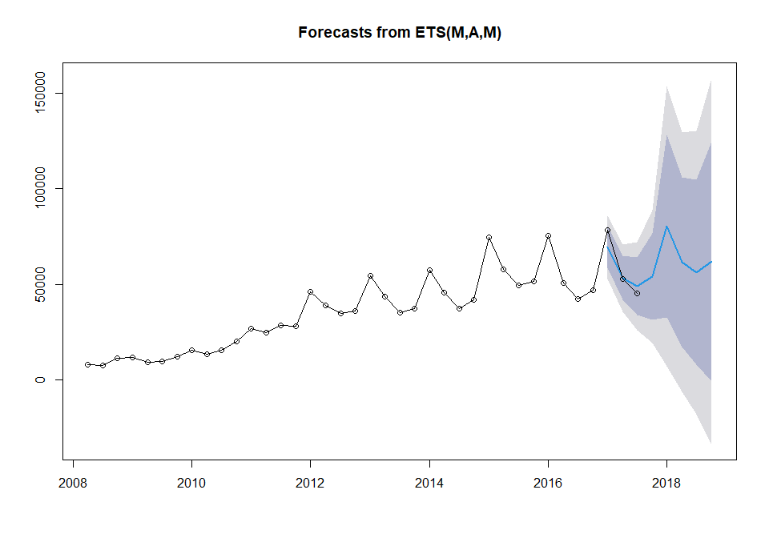

```r
plot(fingresos.ets)
lines(window(zIngresos),type="o")
```

Se puede ver a simple vista que predice bastante bien.

# Modelo ARIMA

Vamos a predecir utilizando los modelos ARIMA, y lo compararemos con el mejor modelo ETS, nos quedaremos con el que tenga menor RMSE.

```r
# Modelo ARIMA
arimafit <- auto.arima(oIngresos,lambda=0)
fingresos.arima<-forecast(arimafit)
summary(fingresos.arima)
```

```
##
## Forecast method: ARIMA(0,1,0)(0,1,0)[4]
##
## Model Information:
## Series: oIngresos
## ARIMA(0,1,0)(0,1,0)[4]
## Box Cox transformation: lambda= 0
##
## sigma^2 estimated as 0.01472:  log likelihood=20.72
## AIC=-39.45   AICc=-39.3   BIC=-38.04
##
## Error measures:
##                     ME     RMSE      MAE       MPE     MAPE      MASE      ACF1
## Training set -764.5058 4786.405 3054.054 -1.321616 8.284962 0.4406634 0.1269135
##
## Forecasts:
##         Point Forecast    Lo 80    Hi 80    Lo 95     Hi 95
## 2017 Q1       68524.50 58656.57 80052.53 54021.77  86920.63
## 2017 Q2       45993.21 36914.17 57305.26 32857.77  64379.78
## 2017 Q3       38534.34 29436.35 50444.28 25525.07  58174.00
## 2017 Q4       42622.67 31230.74 58169.99 26490.28  68579.55
## 2018 Q1       62338.78 40156.60 96774.23 31816.09 122143.34
## 2018 Q2       41841.40 24416.21 71702.49 18358.80  95360.44
## 2018 Q3       35055.84 18821.04 65294.59 13541.05  90754.54
## 2018 Q4       38775.11 19344.31 77723.59 13387.03 112310.89
```

Comparando el RMSE del modelo ARIMA (4786.40) con el RMSE del mejor modelo ETS (4120.15), escogeremos el modelo ETS para realizar la predicción sobre el total de los datos para el año 2017 y 2018.

# Predicción del modelo ETS con todos los datos hasta el Q3 2017

```r
tIngresos <- window(zIngresos,start=index(zIngresos[1]),end=index(zIngresos[nObs]))  # seleccionamos todos los datos

etsfitfin<-ets(tIngresos)  # seleccionamos el mejor modelo ets

fingresosfin.ets<-forecast(etsfitfin) # realizamos la prediccion del modelo

summary(fingresosfin.ets) # summary para ver las predicciones en numeros
```

```
##
## Forecast method: ETS(M,A,M)
##
## Model Information:
## ETS(M,A,M)
##
## Call:
##  ets(y = tIngresos)
##
##   Smoothing parameters:
##     alpha = 0.5991
##     beta  = 0.2539
##     gamma = 0.4009
##
##   Initial states:
##     l = 7140.8505
##     b = 1484.7701
##     s = 1.2064 1.0605 0.8277 0.9053
##
##   sigma:  0.1185
##
##      AIC     AICc      BIC
## 768.9828 775.4114 783.7211
##
## Error measures:
##                     ME     RMSE      MAE        MPE    MAPE      MASE      ACF1
## Training set -57.60457 4360.538 3147.605 -0.7769741 8.96196 0.4793365 0.2232266
##
## Forecasts:
##         Point Forecast    Lo 80     Hi 80     Lo 95     Hi 95
## 2017 Q4       49662.41 42121.86  57202.95 38130.135  61194.68
## 2018 Q1       78162.11 62539.72  93784.50 54269.720 102054.50
## 2018 Q2       53196.80 39286.87  67106.74 31923.394  74470.21
## 2018 Q3       46054.27 30686.18  61422.36 22550.808  69557.74
## 2018 Q4       50809.93 27813.57  73806.30 15640.029  85979.84
## 2019 Q1       79964.34 37167.26 122761.41 14511.853 145416.82
## 2019 Q2       54420.81 20322.63  88518.98  2272.141 106569.47
## 2019 Q3       47111.71 12912.74  81310.67 -5191.094  99414.51
```

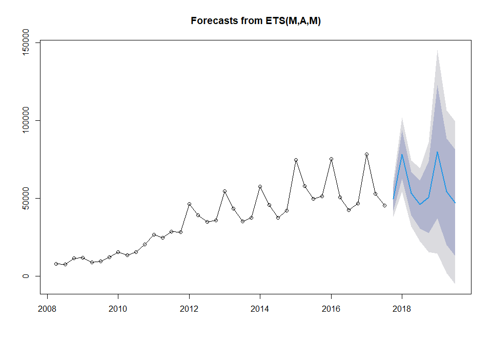

```r
plot(fingresosfin.ets) # grafico para ver la prediccion de manera visual
lines(window(zIngresos),type="o")
```